# RP2 Analysis: Vietnamese Lexical Decision Task

Dang Nhat Quang

This document is an analysis draft for the RP2 Vietnamese lexical decision task. The aim is to check the cleaned data, describe the main patterns, and fit the first mixed-effects models for reaction time. Python was used before this step only to create cleaned data files and quality-control outputs. The raw PsychoPy files are not edited here.

To render from the project root, run:

```r
rmarkdown::render(
  "analysis/RP2_final_analysis_v2.Rmd",
  output_file = "RP2_final_analysis_v2.html",
  output_dir = "analysis/outputs/r_analysis"
)
```

## Libraries and data

The analysis uses `tidyverse` for data handling and plotting, `lme4` and `lmerTest` for mixed-effects models, `car` for VIF checks, and `knitr` for readable tables. Packages are checked first, but they are not installed automatically.

```r
# Check packages before running the analysis
required_packages <- c("tidyverse", "lme4", "lmerTest", "car", "knitr")
optional_packages <- c("broom.mixed")

missing_required <- required_packages[
  !vapply(required_packages, requireNamespace, logical(1), quietly = TRUE)
]
missing_optional <- optional_packages[
  !vapply(optional_packages, requireNamespace, logical(1), quietly = TRUE)
]

if (length(missing_required) > 0) {
  message("Missing required packages: ", paste(missing_required, collapse = ", "))
}

if (length(missing_optional) > 0) {
  message("Missing optional packages: ", paste(missing_optional, collapse = ", "))
}

library(tidyverse)
library(lme4)
library(lmerTest)
library(car)
```

```r
library(knitr)

if (requireNamespace("broom.mixed", quietly = TRUE)) {
  library(broom.mixed)
}

# Keep paths stable when knitting from different folders
project_root <- if (file.exists("analysis/outputs/cleaned_data/rt_realword_correct.csv")) {
  "."
} else if (file.exists("outputs/cleaned_data/rt_realword_correct.csv")) {
  ".."
} else {
  stop("Cleaned data files were not found. Run python analysis/01_prepare_clean_data.py first.")
}

project_path <- function(...) file.path(project_root, ...)

table_dir <- project_path("analysis", "outputs", "r_analysis", "tables")
figure_dir <- project_path("analysis", "outputs", "r_analysis", "figures")
model_dir <- project_path("analysis", "outputs", "r_analysis", "models")

dir.create(table_dir, recursive = TRUE, showWarnings = FALSE)
dir.create(figure_dir, recursive = TRUE, showWarnings = FALSE)
dir.create(model_dir, recursive = TRUE, showWarnings = FALSE)
```

## Read in data

Three cleaned files are read. `rt_data` is the main file for RT modeling because it contains only correct real-word main trials with valid RTs. `acc_data` contains all main trials and is used for accuracy summaries. `main_data` is kept for general checking.

```r
# Read cleaned analysis files
rt_data <- readr::read_csv(
  project_path("analysis", "outputs", "cleaned_data", "rt_realword_correct.csv"),
  show_col_types = FALSE
)

acc_data <- readr::read_csv(
  project_path("analysis", "outputs", "cleaned_data", "accuracy_main_trials.csv"),
  show_col_types = FALSE
)

main_data <- readr::read_csv(
  project_path("analysis", "outputs", "cleaned_data", "main_trials_clean.csv"),
  show_col_types = FALSE
)
```

```r
# Inspect the basic structure before modeling
summary(rt_data)
```

```
##  participant_id        block           trial_id         stimulus
##  Min.   : 1.00   Length   :3306   Length   :3306   Length   :3306
##  1st Qu.:12.00   N.unique :   1   N.unique :  72   N.unique : 130
##  Median :24.00   N.blank  :   0   N.blank  :   0   N.blank  :   0
##  Mean   :24.33   Min.nchar:   4   Min.nchar:  10   Min.nchar:   2
##  3rd Qu.:36.00   Max.nchar:   4   Max.nchar:  10   Max.nchar:  20
##  Max.   :48.00
##      condition       is_word  syllable_length  frequency_group
##  Length   :3306   Min.   :1   Min.   :1.000   Length   :3306
##  N.unique :   1   1st Qu.:1   1st Qu.:1.000   N.unique :   3
##  N.blank  :   0   Median :1   Median :2.000   N.blank  :   0
##  Min.nchar:   4   Mean   :1   Mean   :2.488   Min.nchar:   3
##  Max.nchar:   4   3rd Qu.:1   3rd Qu.:3.000   Max.nchar:   4
##                   Max.   :1   Max.   :4.000
##    frequency       log_frequency    source_realword  correct_response
##  Min.   :   3.00   Min.   :1.099   Length   :3306   Length   :3306
##  1st Qu.:  10.00   1st Qu.:2.303   N.unique : 130   N.unique :   1
##  Median :  18.00   Median :2.890   N.blank  :   0   N.blank  :   0
##  Mean   :  94.07   Mean   :3.241   Min.nchar:   2   Min.nchar:   4
##  3rd Qu.:  60.00   3rd Qu.:4.094   Max.nchar:  20   Max.nchar:   4
##  Max.   :1464.00   Max.   :7.289
##  key_pressed       response_label    accuracy       rt            source_file
##  Mode :logical   Length   :3306   Min.   :1   Min.   :0.2750   Length   :3306
##  FALSE:3306      N.unique :   1   1st Qu.:1   1st Qu.:0.4443   N.unique :  48
##                  N.blank  :   0   Median :1   Median :0.5735   N.blank  :   0
##                  Min.nchar:   4   Mean   :1   Mean   :0.5987   Min.nchar:  37
##                  Max.nchar:   4   3rd Qu.:1   3rd Qu.:0.7208   Max.nchar:  38
##                                   Max.   :1   Max.   :2.1576
##   source_encoding  row_in_file          item_id       rt_numeric
##  Length   :3306   Min.   :  5.00   Length   :3306   Min.   :0.2750
##  N.unique :   2   1st Qu.: 36.00   N.unique :  72   1st Qu.:0.4443
##  N.blank  :   0   Median : 65.00   N.blank  :   0   Median :0.5735
##  Min.nchar:   6   Mean   : 65.73   Min.nchar:  10   Mean   :0.5987
##  Max.nchar:   9   3rd Qu.: 96.00   Max.nchar:  10   3rd Qu.:0.7208
##                   Max.   :124.00                    Max.   :2.1576
##      log_rt        is_timeout      is_main_trial  is_practice_trial
##  Min.   :-1.2910   Mode :logical   Mode:logical   Mode :logical
##  1st Qu.:-0.8112   FALSE:3306      TRUE:3306      FALSE:3306
##  Median :-0.5560
##  Mean   :-0.5725
##  3rd Qu.:-0.3273
##  Max.   : 0.7690
##  is_real_word   is_pseudoword   is_correct     accuracy_numeric
##  Mode:logical   Mode :logical   Mode:logical   Min.   :1
##  TRUE:3306      FALSE:3306      TRUE:3306      1st Qu.:1
##                                                Median :1
##                                                Mean   :1
##                                                3rd Qu.:1
##                                                Max.   :1
##  syllable_length_numeric frequency_numeric log_frequency_numeric
##  Min.   :1.000           Min.   :   3.00   Min.   :1.099
##  1st Qu.:1.000           1st Qu.:  10.00   1st Qu.:2.303
##  Median :2.000           Median :  18.00   Median :2.890
##  Mean   :2.488           Mean   :  94.07   Mean   :3.241
##  3rd Qu.:3.000           3rd Qu.:  60.00   3rd Qu.:4.094
##  Max.   :4.000           Max.   :1464.00   Max.   :7.289
```

```r
summary(acc_data)
```

```
##  participant_id        block           trial_id         stimulus
##  Min.   : 1.00   Length   :5760   Length   :5760   Length   :5760
##  1st Qu.:12.75   N.unique :   1   N.unique : 120   N.unique : 214
##  Median :24.50   N.blank  :   0   N.blank  :   0   N.blank  :   0
##  Mean   :24.50   Min.nchar:   4   Min.nchar:  10   Min.nchar:   2
##  3rd Qu.:36.25   Max.nchar:   4   Max.nchar:  10   Max.nchar:  20
##  Max.   :48.00
##
##      condition       is_word    syllable_length  frequency_group
##  Length   :5760   Min.   :0.0   Min.   :1.00    Length   :5760
##  N.unique :   2   1st Qu.:0.0   1st Qu.:1.75    N.unique :   4
##  N.blank  :   0   Median :1.0   Median :2.50    N.blank  :   0
##  Min.nchar:   4   Mean   :0.6   Mean   :2.50    Min.nchar:   3
##  Max.nchar:  10   3rd Qu.:1.0   3rd Qu.:3.25    Max.nchar:   7
##                   Max.   :1.0   Max.   :4.00
##
##    frequency       log_frequency    source_realword  correct_response
##  Min.   :   3.00   Min.   :1.099   Length   :5760   Length   :5760
##  1st Qu.:   9.75   1st Qu.:2.276   N.unique : 173   N.unique :   2
##  Median :  18.00   Median :2.890   N.blank  :   0   N.blank  :   0
##  Mean   :  92.11   Mean   :3.228   Min.nchar:   2   Min.nchar:   4
##  3rd Qu.:  51.00   3rd Qu.:3.927   Max.nchar:  20   Max.nchar:   7
##  Max.   :1464.00   Max.   :7.289
##  NAs    :2304      NAs    :2304
##     key_pressed     response_label    accuracy            rt
##  Length   :5760   Length   :5760   Min.   :0.0000   Min.   :0.2728
##  N.unique :   2   N.unique :   2   1st Qu.:1.0000   1st Qu.:0.5160
##  N.blank  :   0   N.blank  :   0   Median :1.0000   Median :0.6830
##  Min.nchar:   1   Min.nchar:   4   Mean   :0.9021   Mean   :0.7215
##  Max.nchar:   1   Max.nchar:   7   3rd Qu.:1.0000   3rd Qu.:0.8886
##  NAs      :  45   NAs      :  45   Max.   :1.0000   Max.   :2.1576
##                                                     NAs    :45
##     source_file    source_encoding  row_in_file          item_id
##  Length   :5760   Length   :5760   Min.   :  5.00   Length   :5760
##  N.unique :  48   N.unique :   2   1st Qu.: 34.75   N.unique : 120
##  N.blank  :   0   N.blank  :   0   Median : 64.50   N.blank  :   0
##  Min.nchar:  37   Min.nchar:   6   Mean   : 64.50   Min.nchar:  10
##  Max.nchar:  38   Max.nchar:   9   3rd Qu.: 94.25   Max.nchar:  10
##                                    Max.   :124.00
##
```

[output cut: 17 more lines]

```
##  Min.   :0.0000   Min.   :1.00            Min.   :   3.00
##  1st Qu.:1.0000   1st Qu.:1.75            1st Qu.:   9.75
##  Median :1.0000   Median :2.50            Median :  18.00
##  Mean   :0.9021   Mean   :2.50            Mean   :  92.11
##  3rd Qu.:1.0000   3rd Qu.:3.25            3rd Qu.:  51.00
##  Max.   :1.0000   Max.   :4.00            Max.   :1464.00
##                                           NAs    :2304
##  log_frequency_numeric
##  Min.   :1.099
##  1st Qu.:2.276
##  Median :2.890
##  Mean   :3.228
##  3rd Qu.:3.927
##  Max.   :7.289
##  NAs    :2304
```

```r
summary(main_data)
```

```
##  participant_id        block           trial_id         stimulus
##  Min.   : 1.00   Length   :5760   Length   :5760   Length   :5760
##  1st Qu.:12.75   N.unique :   1   N.unique : 120   N.unique : 214
##  Median :24.50   N.blank  :   0   N.blank  :   0   N.blank  :   0
##  Mean   :24.50   Min.nchar:   4   Min.nchar:  10   Min.nchar:   2
##  3rd Qu.:36.25   Max.nchar:   4   Max.nchar:  10   Max.nchar:  20
##  Max.   :48.00
##
##      condition       is_word    syllable_length  frequency_group
##  Length   :5760   Min.   :0.0   Min.   :1.00    Length   :5760
##  N.unique :   2   1st Qu.:0.0   1st Qu.:1.75    N.unique :   4
##  N.blank  :   0   Median :1.0   Median :2.50    N.blank  :   0
##  Min.nchar:   4   Mean   :0.6   Mean   :2.50    Min.nchar:   3
##  Max.nchar:  10   3rd Qu.:1.0   3rd Qu.:3.25    Max.nchar:   7
##                   Max.   :1.0   Max.   :4.00
##
##    frequency       log_frequency    source_realword  correct_response
##  Min.   :   3.00   Min.   :1.099   Length   :5760   Length   :5760
##  1st Qu.:   9.75   1st Qu.:2.276   N.unique : 173   N.unique :   2
##  Median :  18.00   Median :2.890   N.blank  :   0   N.blank  :   0
##  Mean   :  92.11   Mean   :3.228   Min.nchar:   2   Min.nchar:   4
##  3rd Qu.:  51.00   3rd Qu.:3.927   Max.nchar:  20   Max.nchar:   7
##  Max.   :1464.00   Max.   :7.289
##  NAs    :2304      NAs    :2304
##     key_pressed     response_label    accuracy            rt
##  Length   :5760   Length   :5760   Min.   :0.0000   Min.   :0.2728
##  N.unique :   2   N.unique :   2   1st Qu.:1.0000   1st Qu.:0.5160
##  N.blank  :   0   N.blank  :   0   Median :1.0000   Median :0.6830
##  Min.nchar:   1   Min.nchar:   4   Mean   :0.9021   Mean   :0.7215
##  Max.nchar:   1   Max.nchar:   7   3rd Qu.:1.0000   3rd Qu.:0.8886
##  NAs      :  45   NAs      :  45   Max.   :1.0000   Max.   :2.1576
##                                                     NAs    :45
##     source_file    source_encoding  row_in_file          item_id
##  Length   :5760   Length   :5760   Min.   :  5.00   Length   :5760
##  N.unique :  48   N.unique :   2   1st Qu.: 34.75   N.unique : 120
##  N.blank  :   0   N.blank  :   0   Median : 64.50   N.blank  :   0
##  Min.nchar:  37   Min.nchar:   6   Mean   : 64.50   Min.nchar:  10
##  Max.nchar:  38   Max.nchar:   9   3rd Qu.: 94.25   Max.nchar:  10
##                                    Max.   :124.00
##
```

[output cut: 17 more lines]

```
##  Min.   :0.0000   Min.   :1.00            Min.   :   3.00
##  1st Qu.:1.0000   1st Qu.:1.75            1st Qu.:   9.75
##  Median :1.0000   Median :2.50            Median :  18.00
##  Mean   :0.9021   Mean   :2.50            Mean   :  92.11
##  3rd Qu.:1.0000   3rd Qu.:3.25            3rd Qu.:  51.00
##  Max.   :1.0000   Max.   :4.00            Max.   :1464.00
##                                           NAs    :2304
##  log_frequency_numeric
##  Min.   :1.099
##  1st Qu.:2.276
##  Median :2.890
##  Mean   :3.228
##  3rd Qu.:3.927
##  Max.   :7.289
##  NAs    :2304
```

```r
# Prepare factors for the experimental design
rt_data <- rt_data %>%
  mutate(
    participant_id = factor(participant_id),
    trial_id = factor(trial_id),
    item_id = factor(item_id),
    frequency_group = factor(frequency_group, levels = c("low", "mid", "high")),
    syllable_length = factor(syllable_length, levels = c("1", "2", "3", "4")),
    log_rt = as.numeric(log_rt),
    rt_numeric = as.numeric(rt_numeric)
  )

acc_data <- acc_data %>%
  mutate(
    participant_id = factor(participant_id),
    trial_id = factor(trial_id),
    item_id = factor(item_id),
    condition = factor(condition),
    frequency_group = factor(frequency_group, levels = c("low", "mid", "high", "control")),
    syllable_length = factor(syllable_length, levels = c("1", "2", "3", "4")),
    accuracy_numeric = as.numeric(accuracy_numeric)
  )

main_data <- main_data %>%
  mutate(
    participant_id = factor(participant_id),
    trial_id = factor(trial_id),
    item_id = factor(item_id),
    condition = factor(condition),
    frequency_group = factor(frequency_group, levels = c("low", "mid", "high", "control")),
    syllable_length = factor(syllable_length, levels = c("1", "2", "3", "4")),
    log_rt = as.numeric(log_rt),
    rt_numeric = as.numeric(rt_numeric),
    accuracy_numeric = as.numeric(accuracy_numeric)
  )
```

## Why mixed-effects modeling is needed

This experiment is a repeated-measures lexical decision task. Each participant responded to many items, and each item was seen by many participants. Therefore, observations are not fully independent. A simple linear model would ignore participant-level and item-level variability. Mixed-effects models are appropriate because they allow participants and items to be modeled as random effects (Baayen, Davidson, & Bates, 2008; Bates et al., 2015).

## Why log RT is used

Reaction-time data are usually right-skewed. For this reason, RT analyses often use transformed RTs or otherwise check distributional assumptions. In this project, `log_rt` is used as the dependent variable for the main RT models. This follows common practice in RT analysis, while the diagnostic plots below are still checked carefully (Baayen & Milin, 2010).

## Summary of data

Before modeling, I first check the number of participants, items, and observations. I also summarize RT and accuracy to make sure the cleaned data look plausible.

```r
# Summarise RT and accuracy data
rt_summary <- rt_data %>%
  summarise(
    participants = n_distinct(participant_id),
    items = n_distinct(trial_id),
    observations = n(),
    mean_rt = mean(rt_numeric, na.rm = TRUE),
    median_rt = median(rt_numeric, na.rm = TRUE),
    min_rt = min(rt_numeric, na.rm = TRUE),
    max_rt = max(rt_numeric, na.rm = TRUE)
  )

accuracy_by_condition <- acc_data %>%
  group_by(condition) %>%
  summarise(
    n = n(),
    accuracy = mean(accuracy_numeric, na.rm = TRUE),
    .groups = "drop"
  )

accuracy_overall <- acc_data %>%
  summarise(
    n = n(),
    accuracy = mean(accuracy_numeric, na.rm = TRUE),
    participants = n_distinct(participant_id)
  )

kable(rt_summary)
```

| participants | items | observations | mean_rt | median_rt | min_rt | max_rt |
| --- | --- | --- | --- | --- | --- | --- |
| 48 | 72 | 3306 | 0.5986884 | 0.5735025 | 0.275 | 2.157564 |

```r
kable(accuracy_overall)
```

| n | accuracy | participants |
| --- | --- | --- |
| 5760 | 0.9020833 | 48 |

```r
kable(accuracy_by_condition)
```

| condition | n | accuracy |
| --- | --- | --- |
| pseudoword | 2304 | 0.8203125 |
| word | 3456 | 0.9565972 |

## Descriptive tables

The following tables summarize the main design variables. These tables are descriptive and should not be interpreted as final inferential results.

```r
# Create descriptive tables for later reporting
rt_by_frequency_group <- rt_data %>%
  group_by(frequency_group) %>%
  summarise(
    n = n(),
    mean_rt = mean(rt_numeric, na.rm = TRUE),
    median_rt = median(rt_numeric, na.rm = TRUE),
    mean_log_rt = mean(log_rt, na.rm = TRUE),
    .groups = "drop"
  )

rt_by_syllable_length <- rt_data %>%
  group_by(syllable_length) %>%
  summarise(
    n = n(),
    mean_rt = mean(rt_numeric, na.rm = TRUE),
    median_rt = median(rt_numeric, na.rm = TRUE),
    mean_log_rt = mean(log_rt, na.rm = TRUE),
    .groups = "drop"
  )

rt_by_frequency_group_x_syllable_length <- rt_data %>%
  group_by(frequency_group, syllable_length) %>%
  summarise(
    n = n(),
    mean_rt = mean(rt_numeric, na.rm = TRUE),
    median_rt = median(rt_numeric, na.rm = TRUE),
    mean_log_rt = mean(log_rt, na.rm = TRUE),
    .groups = "drop"
  )

accuracy_by_syllable_length <- acc_data %>%
  group_by(syllable_length) %>%
  summarise(
    n = n(),
    accuracy = mean(accuracy_numeric, na.rm = TRUE),
    .groups = "drop"
  )

accuracy_by_frequency_group_realwords <- acc_data %>%
  filter(condition == "word") %>%
  group_by(frequency_group) %>%
  summarise(
    n = n(),
    accuracy = mean(accuracy_numeric, na.rm = TRUE),
    .groups = "drop"
  )

readr::write_csv(rt_by_frequency_group, file.path(table_dir, "rt_by_frequency_group_v2.csv"))
readr::write_csv(rt_by_syllable_length, file.path(table_dir, "rt_by_syllable_length_v2.csv"))
readr::write_csv(
  rt_by_frequency_group_x_syllable_length,
  file.path(table_dir, "rt_by_frequency_group_x_syllable_length_v2.csv")
)
readr::write_csv(accuracy_by_condition, file.path(table_dir, "accuracy_by_condition_v2.csv"))
readr::write_csv(accuracy_by_syllable_length, file.path(table_dir, "accuracy_by_syllable_length_v2.csv"))
readr::write_csv(
  accuracy_by_frequency_group_realwords,
  file.path(table_dir, "accuracy_by_frequency_group_realwords_v2.csv")
)

kable(rt_by_frequency_group)
```

| frequency_group | n | mean_rt | median_rt | mean_log_rt |
| --- | --- | --- | --- | --- |
| low | 1098 | 0.6675688 | 0.6396325 | -0.4538327 |
| mid | 1104 | 0.6183945 | 0.5931725 | -0.5392981 |
| high | 1104 | 0.5104762 | 0.4949405 | -0.7237960 |

```r
kable(rt_by_syllable_length)
```

| syllable_length | n | mean_rt | median_rt | mean_log_rt |
| --- | --- | --- | --- | --- |
| 1 | 840 | 0.4406149 | 0.4263330 | -0.8602142 |
| 2 | 831 | 0.5280353 | 0.5170910 | -0.6750479 |
| 3 | 816 | 0.6838730 | 0.6651825 | -0.4239402 |
| 4 | 819 | 0.7476307 | 0.7370130 | -0.3214704 |

```r
kable(rt_by_frequency_group_x_syllable_length)
```

| frequency_group | syllable_length | n | mean_rt | median_rt | mean_log_rt |
| --- | --- | --- | --- | --- | --- |
| low | 1 | 276 | 0.4678951 | 0.4684370 | -0.7804683 |
| low | 2 | 277 | 0.6053316 | 0.6109160 | -0.5265311 |
| low | 3 | 278 | 0.7624469 | 0.7442315 | -0.3019350 |
| low | 4 | 267 | 0.8397542 | 0.8570610 | -0.1989214 |
| mid | 1 | 281 | 0.4664175 | 0.4452900 | -0.8132386 |
| mid | 2 | 276 | 0.5369000 | 0.5296890 | -0.6527913 |
| mid | 3 | 270 | 0.7122647 | 0.6957975 | -0.3869993 |
| mid | 4 | 277 | 0.7622682 | 0.7630900 | -0.2967683 |
| high | 1 | 283 | 0.3883893 | 0.3605960 | -0.9846313 |
| high | 2 | 278 | 0.4422161 | 0.4304335 | -0.8451268 |
| high | 3 | 268 | 0.5737637 | 0.5709435 | -0.5877144 |
| high | 4 | 275 | 0.6434431 | 0.6322130 | -0.4653360 |

## Exploring the data employing graphics

The plots below follow the same general logic as the course examples. They are simple visual checks before modeling. They show whether the expected frequency and syllable-length patterns are visible descriptively.

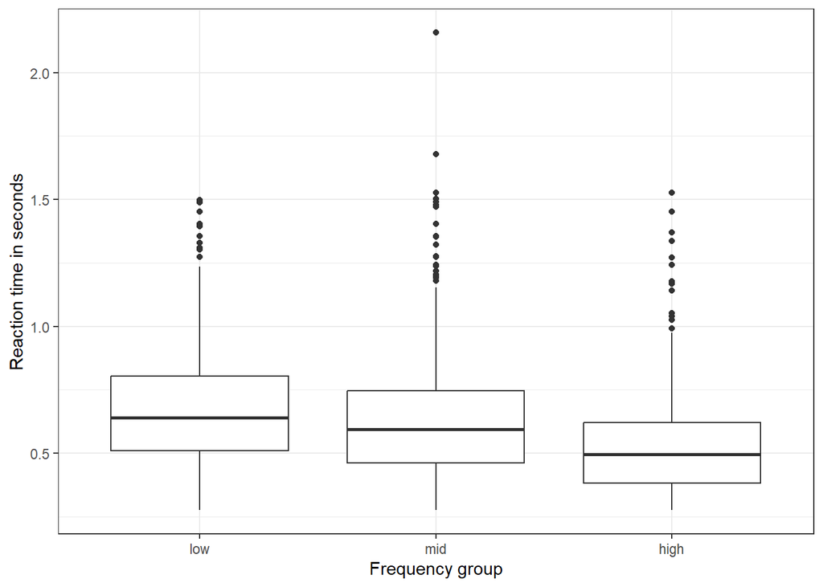

```r
# Plot RT and accuracy patterns
p_rt_frequency <- ggplot(rt_data, aes(x = frequency_group, y = rt_numeric)) +
  geom_boxplot() +
  theme_bw() +
  labs(x = "Frequency group", y = "Reaction time in seconds")

p_rt_length <- ggplot(rt_data, aes(x = syllable_length, y = rt_numeric)) +
  geom_boxplot() +
  theme_bw() +
  labs(x = "Syllable length", y = "Reaction time in seconds")

p_rt_interaction <- ggplot(
  rt_by_frequency_group_x_syllable_length,
  aes(x = syllable_length, y = mean_rt, color = frequency_group, group = frequency_group)
) +
  geom_point() +
  geom_line() +
  theme_bw() +
  labs(x = "Syllable length", y = "Mean reaction time", color = "Frequency group")

p_accuracy_condition <- ggplot(accuracy_by_condition, aes(x = condition, y = accuracy)) +
  geom_col() +
  theme_bw() +
  coord_cartesian(ylim = c(0, 1)) +
  labs(x = "Condition", y = "Accuracy")

ggsave(file.path(figure_dir, "rt_by_frequency_group_boxplot_v2.png"), p_rt_frequency, width = 7, height = 5, dpi = 300)
ggsave(file.path(figure_dir, "rt_by_syllable_length_boxplot_v2.png"), p_rt_length, width = 7, height = 5, dpi = 300)
ggsave(file.path(figure_dir, "rt_frequency_by_length_interaction_v2.png"), p_rt_interaction, width = 7, height = 5, dpi = 300)
ggsave(file.path(figure_dir, "accuracy_by_condition_barplot_v2.png"), p_accuracy_condition, width = 7, height = 5, dpi = 300)

p_rt_frequency
```

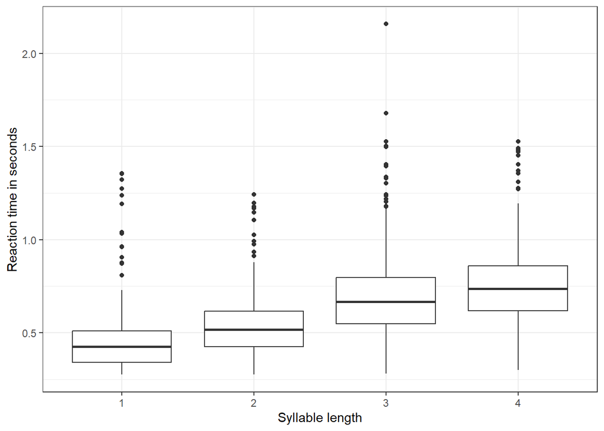

```r
p_rt_length
```

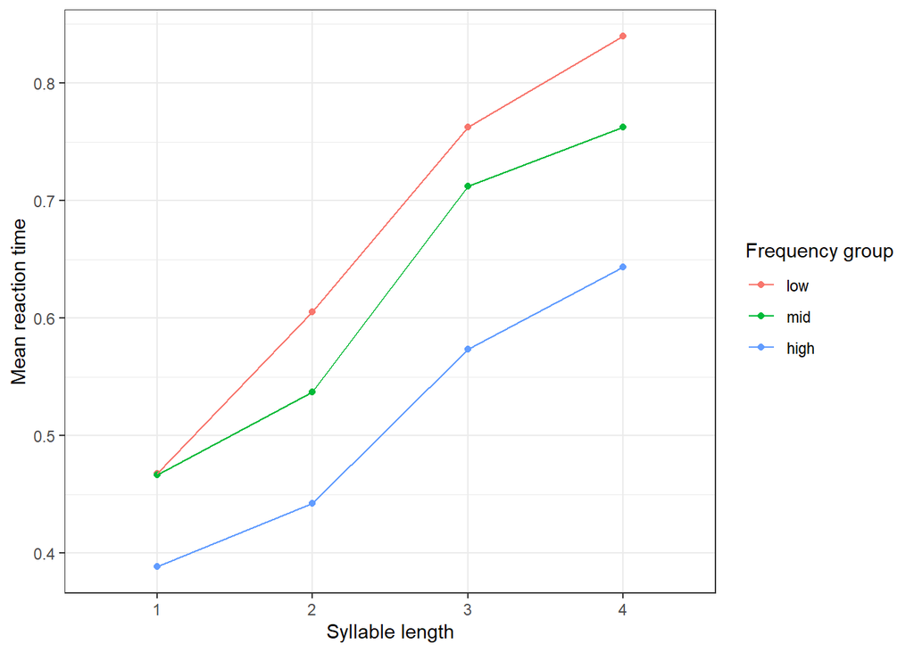

```r
p_rt_interaction
```

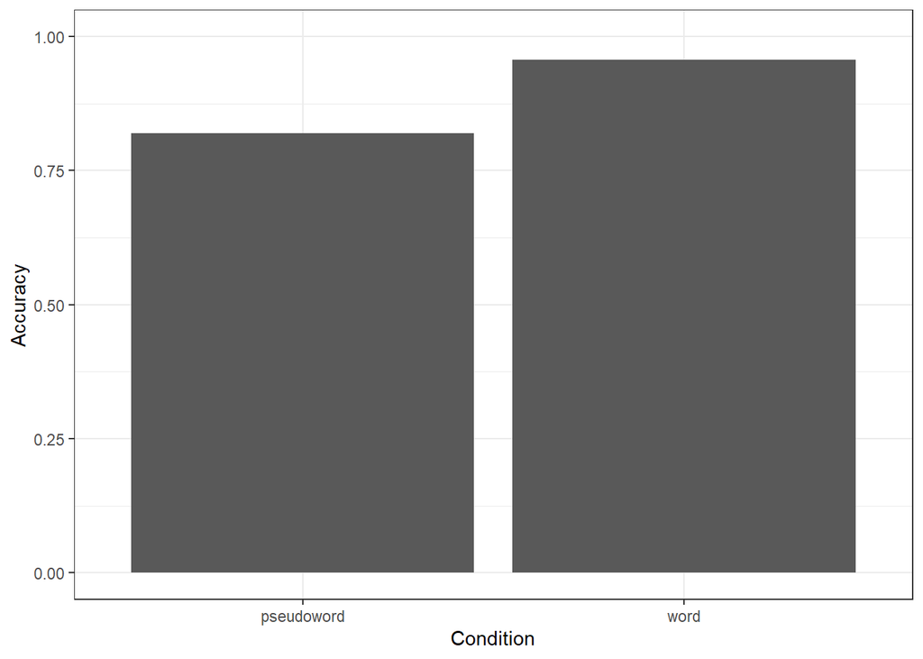

```r
p_accuracy_condition
```

## First model

The first model is an intercept-only mixed-effects model. It is used as a baseline model with random intercepts for participants and items.

```r
# Fit baseline mixed model
model0 <- lmerTest::lmer(
  log_rt ~ 1 + (1 | participant_id) + (1 | trial_id),
  data = rt_data,
  REML = FALSE
)

summary(model0)
```

```
## Linear mixed model fit by maximum likelihood . t-tests use Satterthwaite's
##   method [lmerModLmerTest]
## Formula: log_rt ~ 1 + (1 | participant_id) + (1 | trial_id)
##    Data: rt_data
##
##       AIC       BIC    logLik -2*log(L)  df.resid
##    -286.3    -261.9     147.1    -294.3      3302
##
## Scaled residuals:
##     Min      1Q  Median      3Q     Max
## -4.2458 -0.5661  0.0102  0.5421  5.2012
##
## Random effects:
##  Groups         Name        Variance Std.Dev.
##  trial_id       (Intercept) 0.05830  0.2415
##  participant_id (Intercept) 0.01500  0.1225
##  Residual                   0.04689  0.2165
## Number of obs: 3306, groups:  trial_id, 72; participant_id, 48
##
## Fixed effects:
##              Estimate Std. Error        df t value Pr(>|t|)
## (Intercept)  -0.57023    0.03371 110.22848  -16.91   <2e-16 ***
## ---
## Signif. codes:  0 '***' 0.001 '**' 0.01 '*' 0.05 '.' 0.1 ' ' 1
```

```r
isSingular(model0)
```

```
## [1] FALSE
```

## Second model

The second model adds `frequency_group`. This tests whether reaction time differs across low, mid, and high frequency words.

```r
# Add frequency group
model1 <- lmerTest::lmer(
  log_rt ~ frequency_group + (1 | participant_id) + (1 | trial_id),
  data = rt_data,
  REML = FALSE
)

summary(model1)
```

```
## Linear mixed model fit by maximum likelihood . t-tests use Satterthwaite's
##   method [lmerModLmerTest]
## Formula: log_rt ~ frequency_group + (1 | participant_id) + (1 | trial_id)
##    Data: rt_data
##
##       AIC       BIC    logLik -2*log(L)  df.resid
##    -299.2    -262.6     155.6    -311.2      3300
##
## Scaled residuals:
##     Min      1Q  Median      3Q     Max
## -4.2445 -0.5654  0.0070  0.5423  5.2024
##
## Random effects:
##  Groups         Name        Variance Std.Dev.
##  trial_id       (Intercept) 0.04584  0.2141
##  participant_id (Intercept) 0.01498  0.1224
##  Residual                   0.04689  0.2165
## Number of obs: 3306, groups:  trial_id, 72; participant_id, 48
##
## Fixed effects:
##                     Estimate Std. Error       df t value Pr(>|t|)
## (Intercept)         -0.45302    0.04759 92.68778  -9.519 2.20e-15 ***
## frequency_groupmid  -0.08438    0.06249 71.91458  -1.350    0.181
## frequency_grouphigh -0.26728    0.06249 71.91516  -4.277 5.74e-05 ***
## ---
## Signif. codes:  0 '***' 0.001 '**' 0.01 '*' 0.05 '.' 0.1 ' ' 1
##
## Correlation of Fixed Effects:
##             (Intr) frqncy_grpm
## frqncy_grpm -0.657
## frqncy_grph -0.657  0.500
```

```r
isSingular(model1)
```

```
## [1] FALSE
```

## Third model

The third model adds `syllable_length`. This tests whether longer Vietnamese lexical items, measured by syllable count, are associated with slower responses.

```r
# Add syllable length
model2 <- lmerTest::lmer(
  log_rt ~ frequency_group + syllable_length + (1 | participant_id) + (1 | trial_id),
  data = rt_data,
  REML = FALSE
)

summary(model2)
```

```
## Linear mixed model fit by maximum likelihood . t-tests use Satterthwaite's
##   method [lmerModLmerTest]
## Formula: log_rt ~ frequency_group + syllable_length + (1 | participant_id) +
##     (1 | trial_id)
##    Data: rt_data
##
##       AIC       BIC    logLik -2*log(L)  df.resid
##    -511.0    -456.1     264.5    -529.0      3297
##
## Scaled residuals:
##     Min      1Q  Median      3Q     Max
## -4.1781 -0.5750  0.0180  0.5292  5.2647
##
## Random effects:
##  Groups         Name        Variance Std.Dev.
##  trial_id       (Intercept) 0.001219 0.03491
##  participant_id (Intercept) 0.014796 0.12164
##  Residual                   0.046882 0.21652
## Number of obs: 3306, groups:  trial_id, 72; participant_id, 48
##
## Fixed effects:
##                     Estimate Std. Error       df t value Pr(>|t|)
## (Intercept)         -0.74289    0.02224 92.13064 -33.406  < 2e-16 ***
## frequency_groupmid  -0.08416    0.01367 71.89040  -6.158  3.8e-08 ***
## frequency_grouphigh -0.26712    0.01367 71.88522 -19.542  < 2e-16 ***
## syllable_length2     0.18572    0.01574 71.10543  11.800  < 2e-16 ***
## syllable_length3     0.43344    0.01577 71.71454  27.478  < 2e-16 ***
## syllable_length4     0.53984    0.01577 71.59833  34.239  < 2e-16 ***
## ---
## Signif. codes:  0 '***' 0.001 '**' 0.01 '*' 0.05 '.' 0.1 ' ' 1
##
## Correlation of Fixed Effects:
##             (Intr) frqncy_grpm frqncy_grph syll_2 syll_3
## frqncy_grpm -0.308
## frqncy_grph -0.309  0.501
## syllbl_lng2 -0.354  0.001       0.001
## syllbl_lng3 -0.354  0.003       0.004       0.498
## syllbl_lng4 -0.352 -0.001       0.000       0.498  0.497
```

```r
isSingular(model2)
```

```
## [1] FALSE
```

## Fourth model interaction

The fourth model adds the interaction between `frequency_group` and `syllable_length`. This tests whether the effect of frequency depends on syllable length. This is relevant because the research question asks not only about main effects, but also whether frequency and length work together in Vietnamese visual word recognition.

```r
# Add the frequency by length interaction
model3 <- lmerTest::lmer(
  log_rt ~ frequency_group * syllable_length + (1 | participant_id) + (1 | trial_id),
  data = rt_data,
  REML = FALSE
)

summary(model3)
```

```
## Linear mixed model fit by maximum likelihood . t-tests use Satterthwaite's
##   method [lmerModLmerTest]
## Formula: log_rt ~ frequency_group * syllable_length + (1 | participant_id) +
##     (1 | trial_id)
##    Data: rt_data
##
##       AIC       BIC    logLik -2*log(L)  df.resid
##    -511.9    -420.4     271.0    -541.9      3291
##
## Scaled residuals:
##     Min      1Q  Median      3Q     Max
## -4.1769 -0.5776  0.0162  0.5265  5.2658
##
## Random effects:
##  Groups         Name        Variance  Std.Dev.
##  trial_id       (Intercept) 0.0008439 0.02905
##  participant_id (Intercept) 0.0148117 0.12170
##  Residual                   0.0468832 0.21653
## Number of obs: 3306, groups:  trial_id, 72; participant_id, 48
##
## Fixed effects:
##                                       Estimate Std. Error        df t value
## (Intercept)                           -0.78351    0.02489 108.85400 -31.484
## frequency_groupmid                    -0.02955    0.02487  70.67654  -1.188
## frequency_grouphigh                   -0.20041    0.02484  70.39404  -8.068
## syllable_length2                       0.25660    0.02492  71.22088  10.299
## syllable_length3                       0.47995    0.02490  71.07867  19.273
## syllable_length4                       0.58476    0.02505  72.70581  23.348
## frequency_groupmid:syllable_length2   -0.09460    0.03520  70.95810  -2.687
## frequency_grouphigh:syllable_length2  -0.11774    0.03517  70.66433  -3.348
## frequency_groupmid:syllable_length3   -0.05387    0.03525  71.31935  -1.528
## frequency_grouphigh:syllable_length3  -0.08525    0.03525  71.32342  -2.419
## frequency_groupmid:syllable_length4   -0.06983    0.03529  71.64272  -1.979
## frequency_grouphigh:syllable_length4  -0.06421    0.03528  71.61836  -1.820
##                                      Pr(>|t|)
## (Intercept)                           < 2e-16 ***
## frequency_groupmid                    0.23862
## frequency_grouphigh                  1.32e-11 ***
## syllable_length2                     9.50e-16 ***
## syllable_length3                      < 2e-16 ***
```

[output cut: 32 more lines]

```
## frqncy_grph:_3  0.250          0.498          0.499
## frqncy_grpm:_4  0.498          0.250          0.497          0.250
## frqncy_grph:_4  0.250          0.497          0.250          0.496
##                frqncy_grpm:_4
## frqncy_grpm
## frqncy_grph
## syllbl_lng2
## syllbl_lng3
## syllbl_lng4
## frqncy_grpm:_2
## frqncy_grph:_2
## frqncy_grpm:_3
## frqncy_grph:_3
## frqncy_grpm:_4
## frqncy_grph:_4  0.504
```

```r
isSingular(model3)
```

```
## [1] FALSE
```

```r
# Record singularity status
singularity_status <- tibble(
  model = c("model0", "model1", "model2", "model3"),
  is_singular = c(
    isSingular(model0),
    isSingular(model1),
    isSingular(model2),
    isSingular(model3)
  )
)

kable(singularity_status)
```

| model | is_singular |
| --- | --- |
| model0 | FALSE |
| model1 | FALSE |
| model2 | FALSE |
| model3 | FALSE |

```r
capture.output(
  singularity_status,
  file = file.path(model_dir, "model_singularity_status_v2.txt")
)
```

## Model comparison

The models are compared with `anova()`. This checks whether adding predictors improves model fit. It does not prove causality. The comparison is used here to see whether frequency group, syllable length, and their interaction improve the model for log RT.

```r
# Compare nested models
model_comparison_rt <- anova(model0, model1, model2, model3)

model_comparison_rt_df <- as.data.frame(model_comparison_rt) %>%
  rownames_to_column("model")

readr::write_csv(model_comparison_rt_df, file.path(table_dir, "model_comparison_rt_v2.csv"))

kable(model_comparison_rt)
```

|  | npar | AIC | BIC | logLik | -2*log(L) | Chisq | Df | Pr(>Chisq) |
| --- | --- | --- | --- | --- | --- | --- | --- | --- |
| model0 | 4 | -286.2781 | -261.8641 | 147.1391 | -294.2781 | NA | NA | NA |
| model1 | 6 | -299.2328 | -262.6118 | 155.6164 | -311.2328 | 16.95468 | 2 | 0.0002081 |
| model2 | 9 | -511.0373 | -456.1058 | 264.5186 | -529.0373 | 217.80451 | 3 | 0.0000000 |
| model3 | 15 | -511.9228 | -420.3704 | 270.9614 | -541.9228 | 12.88549 | 6 | 0.0448908 |

## Main model summary

The interaction model is printed below because it directly corresponds to the full planned design. If the interaction model does not improve fit, the additive model may be easier to interpret.

```r
# Save the full model summary
summary(model3)
```

```
## Linear mixed model fit by maximum likelihood . t-tests use Satterthwaite's
##   method [lmerModLmerTest]
## Formula: log_rt ~ frequency_group * syllable_length + (1 | participant_id) +
##     (1 | trial_id)
##    Data: rt_data
##
##       AIC       BIC    logLik -2*log(L)  df.resid
##    -511.9    -420.4     271.0    -541.9      3291
##
## Scaled residuals:
##     Min      1Q  Median      3Q     Max
## -4.1769 -0.5776  0.0162  0.5265  5.2658
##
## Random effects:
##  Groups         Name        Variance  Std.Dev.
##  trial_id       (Intercept) 0.0008439 0.02905
##  participant_id (Intercept) 0.0148117 0.12170
##  Residual                   0.0468832 0.21653
## Number of obs: 3306, groups:  trial_id, 72; participant_id, 48
##
## Fixed effects:
##                                       Estimate Std. Error        df t value
## (Intercept)                           -0.78351    0.02489 108.85400 -31.484
## frequency_groupmid                    -0.02955    0.02487  70.67654  -1.188
## frequency_grouphigh                   -0.20041    0.02484  70.39404  -8.068
## syllable_length2                       0.25660    0.02492  71.22088  10.299
## syllable_length3                       0.47995    0.02490  71.07867  19.273
## syllable_length4                       0.58476    0.02505  72.70581  23.348
## frequency_groupmid:syllable_length2   -0.09460    0.03520  70.95810  -2.687
## frequency_grouphigh:syllable_length2  -0.11774    0.03517  70.66433  -3.348
## frequency_groupmid:syllable_length3   -0.05387    0.03525  71.31935  -1.528
## frequency_grouphigh:syllable_length3  -0.08525    0.03525  71.32342  -2.419
## frequency_groupmid:syllable_length4   -0.06983    0.03529  71.64272  -1.979
## frequency_grouphigh:syllable_length4  -0.06421    0.03528  71.61836  -1.820
##                                      Pr(>|t|)
## (Intercept)                           < 2e-16 ***
## frequency_groupmid                    0.23862
## frequency_grouphigh                  1.32e-11 ***
## syllable_length2                     9.50e-16 ***
## syllable_length3                      < 2e-16 ***
```

[output cut: 32 more lines]

```
## frqncy_grph:_3  0.250          0.498          0.499
## frqncy_grpm:_4  0.498          0.250          0.497          0.250
## frqncy_grph:_4  0.250          0.497          0.250          0.496
##                frqncy_grpm:_4
## frqncy_grpm
## frqncy_grph
## syllbl_lng2
## syllbl_lng3
## syllbl_lng4
## frqncy_grpm:_2
## frqncy_grph:_2
## frqncy_grpm:_3
## frqncy_grph:_3
## frqncy_grpm:_4
## frqncy_grph:_4  0.504
```

```r
capture.output(
  summary(model3),
  file = file.path(model_dir, "model3_rt_summary_v2.txt")
)
```

## Assumptions and diagnostics

Mixed-effects model diagnostics are not identical to simple `lm()` diagnostics. However, residual plots are still useful for checking strong problems such as clear nonlinearity, heteroscedasticity, or non-normal residuals.

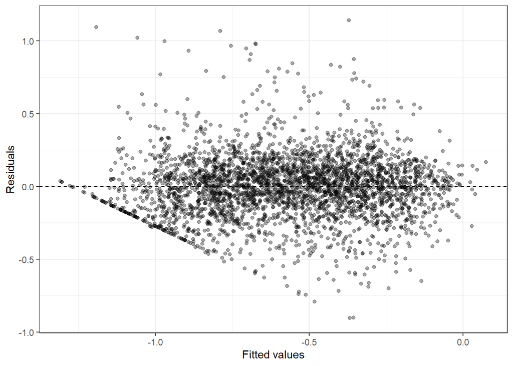

```r
# Create residual diagnostics
diag_data <- tibble(
  fitted = fitted(model3),
  residuals = resid(model3),
  frequency_group = rt_data$frequency_group,
  syllable_length = rt_data$syllable_length
)

p_resid_fitted <- ggplot(diag_data, aes(x = fitted, y = residuals)) +
  geom_point(alpha = 0.35) +
  geom_hline(yintercept = 0, linetype = "dashed") +
  theme_bw() +
  labs(x = "Fitted values", y = "Residuals")

p_resid_hist <- ggplot(diag_data, aes(x = residuals)) +
  geom_histogram(bins = 40) +
  theme_bw() +
  labs(x = "Residuals", y = "Count")

p_resid_qq <- ggplot(diag_data, aes(sample = residuals)) +
  stat_qq() +
  stat_qq_line() +
  theme_bw() +
  labs(x = "Theoretical quantiles", y = "Sample quantiles")

p_resid_length <- ggplot(diag_data, aes(x = syllable_length, y = residuals)) +
  geom_boxplot() +
  theme_bw() +
  labs(x = "Syllable length", y = "Residuals")

ggsave(file.path(figure_dir, "model3_residuals_vs_fitted_v2.png"), p_resid_fitted, width = 7, height = 5, dpi = 300)
ggsave(file.path(figure_dir, "model3_residual_histogram_v2.png"), p_resid_hist, width = 7, height = 5, dpi = 300)
ggsave(file.path(figure_dir, "model3_residual_qqplot_v2.png"), p_resid_qq, width = 7, height = 5, dpi = 300)
ggsave(file.path(figure_dir, "model3_residuals_by_length_v2.png"), p_resid_length, width = 7, height = 5, dpi = 300)

p_resid_fitted
```

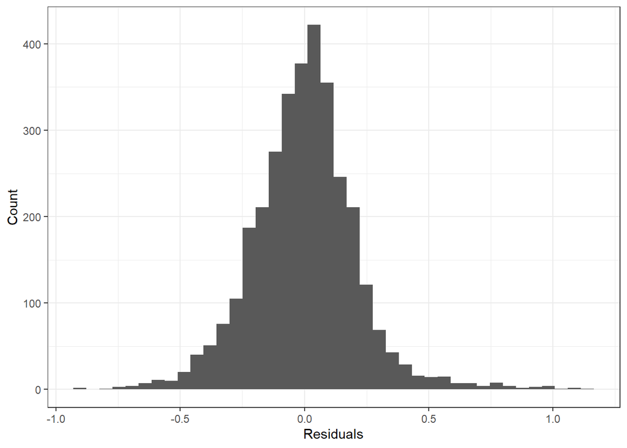

```r
p_resid_hist
```

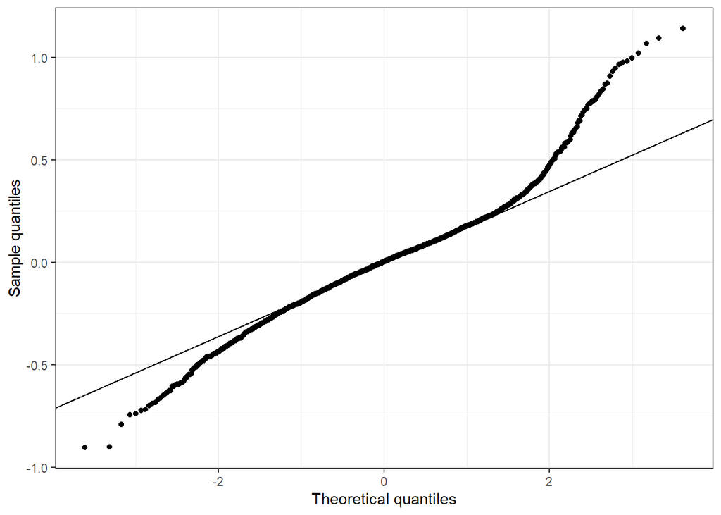

```r
p_resid_qq
```

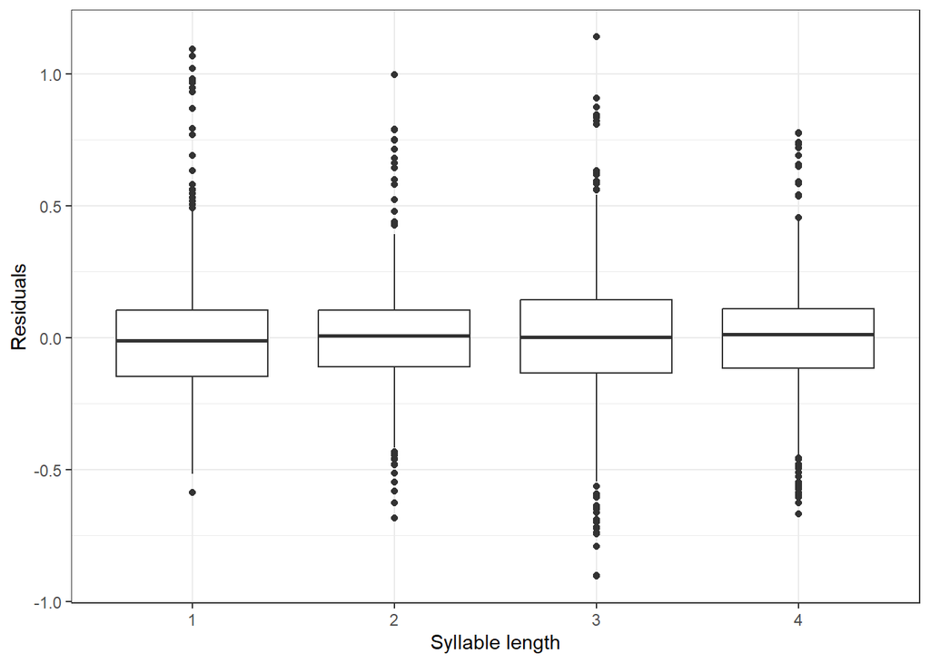

```r
p_resid_length
```

```r
# Check fixed effect collinearity with an lm approximation
fixed_lm <- lm(log_rt ~ frequency_group * syllable_length, data = rt_data)
vif_output <- car::vif(fixed_lm)
```

```
## there are higher-order terms (interactions) in this model
## consider setting type = 'predictor'; see ?vif
```

```r
capture.output(
  vif_output,
  file = file.path(model_dir, "vif_fixed_effects_v2.txt")
)

vif_output
```

```
##                                      GVIF Df GVIF^(1/(2*Df))
## frequency_group                  15.49227  2        1.983941
## syllable_length                  27.30291  3        1.735274
## frequency_group:syllable_length 210.33819  6        1.561624
```

## Random effects note

Participants and items are included as random intercepts because both can introduce variability. Some participants are generally faster or slower, and some items are generally easier or harder. Including both random effects follows the logic of crossed random effects for subjects and items (Baayen et al., 2008).

```r
# Save random effects for inspection
capture.output(
  ranef(model3),
  file = file.path(model_dir, "model3_random_effects_v2.txt")
)

VarCorr(model3)
```

```
##  Groups         Name        Std.Dev.
##  trial_id       (Intercept) 0.029049
##  participant_id (Intercept) 0.121704
##  Residual                   0.216525
```

## Interaction plotting

The plot below shows fitted values from the interaction model without participant or item random effects. It helps visualize the fixed-effect pattern from the full model.

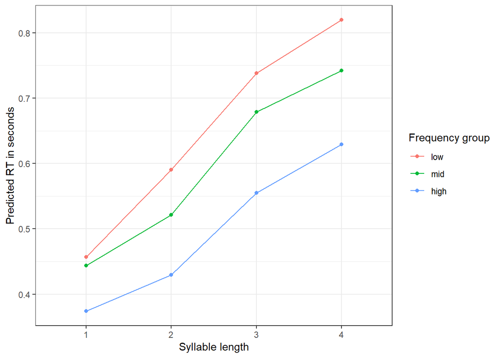

```r
# Plot fixed effect predictions from model3
prediction_grid <- expand.grid(
  frequency_group = levels(rt_data$frequency_group),
  syllable_length = levels(rt_data$syllable_length)
)

prediction_grid$predicted_log_rt <- predict(
  model3,
  newdata = prediction_grid,
  re.form = NA
)

prediction_grid$predicted_rt <- exp(prediction_grid$predicted_log_rt)

p_model_interaction <- ggplot(
  prediction_grid,
  aes(x = syllable_length, y = predicted_rt, color = frequency_group, group = frequency_group)
) +
  geom_point() +
  geom_line() +
  theme_bw() +
  labs(x = "Syllable length", y = "Predicted RT in seconds", color = "Frequency group")

ggsave(file.path(figure_dir, "model3_predicted_interaction_v2.png"), p_model_interaction, width = 7, height = 5, dpi = 300)

p_model_interaction
```

## Accuracy analysis

Accuracy is not the main dependent variable, but it is important for checking whether participants performed the task seriously. I first keep this descriptive. A logistic mixed-effects model is included only as supplementary and exploratory.

```r
# Summarise accuracy patterns
accuracy_real_pseudo <- acc_data %>%
  group_by(condition) %>%
  summarise(
    n = n(),
    accuracy = mean(accuracy_numeric, na.rm = TRUE),
    .groups = "drop"
  )

accuracy_length <- acc_data %>%
  group_by(syllable_length) %>%
  summarise(
    n = n(),
    accuracy = mean(accuracy_numeric, na.rm = TRUE),
    .groups = "drop"
  )

accuracy_frequency_real <- acc_data %>%
  filter(condition == "word") %>%
  group_by(frequency_group) %>%
  summarise(
    n = n(),
    accuracy = mean(accuracy_numeric, na.rm = TRUE),
    .groups = "drop"
  )

kable(accuracy_real_pseudo)
```

| condition | n | accuracy |
| --- | --- | --- |
| pseudoword | 2304 | 0.8203125 |
| word | 3456 | 0.9565972 |

```r
kable(accuracy_length)
```

| syllable_length | n | accuracy |
| --- | --- | --- |
| 1 | 1440 | 0.9020833 |
| 2 | 1440 | 0.9125000 |
| 3 | 1440 | 0.9048611 |
| 4 | 1440 | 0.8888889 |

```r
kable(accuracy_frequency_real)
```

| frequency_group | n | accuracy |
| --- | --- | --- |
| low | 1152 | 0.9531250 |
| mid | 1152 | 0.9583333 |
| high | 1152 | 0.9583333 |

```r
# Fit exploratory accuracy model
accuracy_model <- glmer(
  accuracy_numeric ~ condition * syllable_length + (1 | participant_id) + (1 | trial_id),
  data = acc_data,
  family = binomial,
  control = glmerControl(optimizer = "bobyqa")
)

summary(accuracy_model)
```

```
## Generalized linear mixed model fit by maximum likelihood (Laplace
##   Approximation) [glmerMod]
##  Family: binomial  ( logit )
## Formula:
## accuracy_numeric ~ condition * syllable_length + (1 | participant_id) +
##     (1 | trial_id)
##    Data: acc_data
## Control: glmerControl(optimizer = "bobyqa")
##
##       AIC       BIC    logLik -2*log(L)  df.resid
##    3357.0    3423.6   -1668.5    3337.0      5750
##
## Scaled residuals:
##     Min      1Q  Median      3Q     Max
## -7.6590  0.1696  0.2243  0.3829  0.7338
##
## Random effects:
##  Groups         Name        Variance Std.Dev.
##  trial_id       (Intercept) 0.0150   0.1225
##  participant_id (Intercept) 0.2351   0.4848
## Number of obs: 5760, groups:  trial_id, 120; participant_id, 48
##
## Fixed effects:
##                                Estimate Std. Error z value Pr(>|z|)
## (Intercept)                     1.43914    0.13221  10.885  < 2e-16 ***
## conditionword                   2.23107    0.23566   9.467  < 2e-16 ***
## syllable_length2                0.29039    0.16303   1.781 0.074887 .
## syllable_length3                0.34443    0.16444   2.095 0.036210 *
## syllable_length4                0.02227    0.15704   0.142 0.887238
## conditionword:syllable_length2 -0.62216    0.31903  -1.950 0.051156 .
## conditionword:syllable_length3 -1.07328    0.30493  -3.520 0.000432 ***
## conditionword:syllable_length4 -0.68221    0.30324  -2.250 0.024469 *
## ---
## Signif. codes:  0 '***' 0.001 '**' 0.01 '*' 0.05 '.' 0.1 ' ' 1
##
## Correlation of Fixed Effects:
##             (Intr) cndtnw syll_2 syll_3 syll_4 cnd:_2 cnd:_3
## conditinwrd -0.387
## syllbl_lng2 -0.567  0.320
## syllbl_lng3 -0.562  0.317  0.458
## syllbl_lng4 -0.591  0.331  0.479  0.475
## cndtnwrd:_2  0.289 -0.737 -0.511 -0.234 -0.245
## cndtnwrd:_3  0.302 -0.772 -0.247 -0.539 -0.256  0.570
## cndtnwrd:_4  0.305 -0.776 -0.248 -0.246 -0.518  0.573  0.599
```

```r
isSingular(accuracy_model)
```

```
## [1] FALSE
```

```r
capture.output(
  summary(accuracy_model),
  file = file.path(model_dir, "accuracy_model_supplementary_v2.txt")
)
```

## Preliminary interpretation

```r
# Extract descriptive values for cautious interpretation
high_mean <- rt_by_frequency_group %>%
  filter(frequency_group == "high") %>%
  pull(mean_rt)

low_mean <- rt_by_frequency_group %>%
  filter(frequency_group == "low") %>%
  pull(mean_rt)

length_means <- rt_by_syllable_length %>%
  arrange(syllable_length)

interaction_p <- model_comparison_rt_df %>%
  filter(model == "model3") %>%
  pull(`Pr(>Chisq)`)

overall_accuracy <- accuracy_overall$accuracy

kable(length_means)
```

| syllable_length | n | mean_rt | median_rt | mean_log_rt |
| --- | --- | --- | --- | --- |
| 1 | 840 | 0.4406149 | 0.4263330 | -0.8602142 |
| 2 | 831 | 0.5280353 | 0.5170910 | -0.6750479 |
| 3 | 816 | 0.6838730 | 0.6651825 | -0.4239402 |
| 4 | 819 | 0.7476307 | 0.7370130 | -0.3214704 |

Descriptively, high-frequency words appear faster than low-frequency words if the high-frequency mean RT is lower. In the current data, the high-frequency mean RT is 0.51 seconds and the low-frequency mean RT is 0.668 seconds.

Descriptively, RT appears to increase with syllable length if the mean RTs rise from one to four syllables. This descriptive pattern should be checked together with the mixed-effects model.

The interaction model is useful because it tests whether the frequency effect changes across syllable lengths. The model comparison table should be used to decide whether this additional complexity is justified. The interaction comparison p-value is 0.0449.

Accuracy is also part of the quality check. The overall accuracy is 0.902, which suggests that participants generally performed the lexical decision task seriously. This is still a preliminary analysis draft. Final report wording should be written only after reviewing the model output, residual plots, singularity status, and VIF results.

## References

Baayen, R. H., Davidson, D. J., & Bates, D. M. (2008). Mixed-effects modeling with crossed random effects for subjects and items. *Journal of Memory and Language, 59*(4), 390-412.

Baayen, R. H., & Milin, P. (2010). Analyzing reaction times. *International Journal of Psychological Research, 3*(2), 12-28.

Bates, D., Mächler, M., Bolker, B., & Walker, S. (2015). Fitting linear mixed-effects models using lme4. *Journal of Statistical Software, 67*(1), 1-48.

Brysbaert, M., Mandera, P., & Keuleers, E. (2018). The word frequency effect in word processing. *Current Directions in Psychological Science, 27*(1), 45-50.

Brysbaert, M., & Stevens, M. (2018). Power analysis and effect size in mixed effects models: A tutorial. *Journal of Cognition, 1*(1), Article 9.

Forster, K. I., & Chambers, S. M. (1973). Lexical access and naming time. *Journal of Verbal Learning and Verbal Behavior, 12*(6), 627-635.

Kuznetsova, A., Brockhoff, P. B., & Christensen, R. H. B. (2017). lmerTest package: Tests in linear mixed effects models. *Journal of Statistical Software, 82*(13), 1-26.

New, B., Ferrand, L., Pallier, C., & Brysbaert, M. (2006). Reexamining the word length effect in visual word recognition: New evidence from the English Lexicon Project. *Psychonomic Bulletin & Review, 13*(1), 45-52.